# Risk Factor Analysis

## Outcome Variable

**Outcome Variable:** haz

## Predictor Variables

**Intervention Variable:** predfeed36

**Adjustment Set:**

- arm
- sex
- month
- brthmon
- W_mage
- meducyrs
- feducyrs
- hhwealth_quart
- hfoodsec
- W_mhtcm
- W_mwtkg
- W_mbmi
- vagbrth
- W_gagebrth
- W_birthwt
- W_birthlen
- W_nrooms
- W_nchldlt5
- W_parity
- impfloor
- impsan
- safeh20
- delta_W_mage
- delta_meducyrs
- delta_feducyrs
- delta_hhwealth_quart
- delta_hfoodsec
- delta_W_mhtcm
- delta_W_mwtkg
- delta_W_mbmi
- delta_vagbrth
- delta_W_gagebrth
- delta_W_birthwt
- delta_W_birthlen
- delta_W_nrooms
- delta_W_nchldlt5
- delta_W_parity
- delta_impfloor
- delta_impsan
- delta_safeh20

## Stratifying Variables

The analysis was stratified on these variable(s):

- agecat
- studyid
- country

## Data Summary

| agecat | studyid | country | predfeed36 | n_cell | n | outcome_variable |
| --- | --- | --- | --- | --- | --- | --- |
| Birth | EE | PAKISTAN | 1 | 3 | 7 | haz |
| Birth | EE | PAKISTAN | 0 | 4 | 7 | haz |
| Birth | GMS-Nepal | NEPAL | 1 | 422 | 526 | haz |
| Birth | GMS-Nepal | NEPAL | 0 | 104 | 526 | haz |
| Birth | JiVitA-3 | BANGLADESH | 1 | 8334 | 10681 | haz |
| Birth | JiVitA-3 | BANGLADESH | 0 | 2347 | 10681 | haz |
| Birth | JiVitA-4 | BANGLADESH | 1 | 1999 | 2517 | haz |
| Birth | JiVitA-4 | BANGLADESH | 0 | 518 | 2517 | haz |
| Birth | MAL-ED | BANGLADESH | 1 | 72 | 221 | haz |
| Birth | MAL-ED | BANGLADESH | 0 | 149 | 221 | haz |
| Birth | MAL-ED | BRAZIL | 1 | 8 | 65 | haz |
| Birth | MAL-ED | BRAZIL | 0 | 57 | 65 | haz |
| Birth | MAL-ED | INDIA | 1 | 4 | 42 | haz |
| Birth | MAL-ED | INDIA | 0 | 38 | 42 | haz |
| Birth | MAL-ED | NEPAL | 1 | 1 | 26 | haz |
| Birth | MAL-ED | NEPAL | 0 | 25 | 26 | haz |
| Birth | MAL-ED | PERU | 1 | 58 | 223 | haz |
| Birth | MAL-ED | PERU | 0 | 165 | 223 | haz |
| Birth | MAL-ED | SOUTH AFRICA | 1 | 2 | 105 | haz |
| Birth | MAL-ED | SOUTH AFRICA | 0 | 103 | 105 | haz |
| Birth | MAL-ED | TANZANIA, UNITED REPUBLIC OF | 1 | 0 | 119 | haz |
| Birth | MAL-ED | TANZANIA, UNITED REPUBLIC OF | 0 | 119 | 119 | haz |
| 6 months | EE | PAKISTAN | 1 | 4 | 9 | haz |
| 6 months | EE | PAKISTAN | 0 | 5 | 9 | haz |
| 6 months | GMS-Nepal | NEPAL | 1 | 422 | 527 | haz |
| 6 months | GMS-Nepal | NEPAL | 0 | 105 | 527 | haz |
| 6 months | JiVitA-3 | BANGLADESH | 1 | 6593 | 8552 | haz |
| 6 months | JiVitA-3 | BANGLADESH | 0 | 1959 | 8552 | haz |
| 6 months | JiVitA-4 | BANGLADESH | 1 | 3253 | 4185 | haz |
| 6 months | JiVitA-4 | BANGLADESH | 0 | 932 | 4185 | haz |
| 6 months | LCNI-5 | MALAWI | 1 | 47 | 272 | haz |
| 6 months | LCNI-5 | MALAWI | 0 | 225 | 272 | haz |
| 6 months | MAL-ED | BANGLADESH | 1 | 81 | 240 | haz |
| 6 months | MAL-ED | BANGLADESH | 0 | 159 | 240 | haz |
| 6 months | MAL-ED | BRAZIL | 1 | 25 | 209 | haz |
| 6 months | MAL-ED | BRAZIL | 0 | 184 | 209 | haz |
| 6 months | MAL-ED | INDIA | 1 | 17 | 233 | haz |
| 6 months | MAL-ED | INDIA | 0 | 216 | 233 | haz |
| 6 months | MAL-ED | NEPAL | 1 | 8 | 235 | haz |
| 6 months | MAL-ED | NEPAL | 0 | 227 | 235 | haz |
| 6 months | MAL-ED | PERU | 1 | 72 | 272 | haz |
| 6 months | MAL-ED | PERU | 0 | 200 | 272 | haz |
| 6 months | MAL-ED | SOUTH AFRICA | 1 | 3 | 250 | haz |
| 6 months | MAL-ED | SOUTH AFRICA | 0 | 247 | 250 | haz |
| 6 months | MAL-ED | TANZANIA, UNITED REPUBLIC OF | 1 | 5 | 243 | haz |
| 6 months | MAL-ED | TANZANIA, UNITED REPUBLIC OF | 0 | 238 | 243 | haz |
| 6 months | SAS-FoodSuppl | INDIA | 1 | 0 | 168 | haz |
| 6 months | SAS-FoodSuppl | INDIA | 0 | 168 | 168 | haz |
| 24 months | EE | PAKISTAN | 1 | 0 | 3 | haz |
| 24 months | EE | PAKISTAN | 0 | 3 | 3 | haz |
| 24 months | GMS-Nepal | NEPAL | 1 | 363 | 446 | haz |
| 24 months | GMS-Nepal | NEPAL | 0 | 83 | 446 | haz |
| 24 months | JiVitA-3 | BANGLADESH | 1 | 3334 | 4334 | haz |
| 24 months | JiVitA-3 | BANGLADESH | 0 | 1000 | 4334 | haz |
| 24 months | JiVitA-4 | BANGLADESH | 1 | 3157 | 4049 | haz |
| 24 months | JiVitA-4 | BANGLADESH | 0 | 892 | 4049 | haz |
| 24 months | LCNI-5 | MALAWI | 1 | 34 | 189 | haz |
| 24 months | LCNI-5 | MALAWI | 0 | 155 | 189 | haz |
| 24 months | MAL-ED | BANGLADESH | 1 | 69 | 212 | haz |
| 24 months | MAL-ED | BANGLADESH | 0 | 143 | 212 | haz |
| 24 months | MAL-ED | BRAZIL | 1 | 20 | 169 | haz |
| 24 months | MAL-ED | BRAZIL | 0 | 149 | 169 | haz |
| 24 months | MAL-ED | INDIA | 1 | 17 | 224 | haz |
| 24 months | MAL-ED | INDIA | 0 | 207 | 224 | haz |
| 24 months | MAL-ED | NEPAL | 1 | 8 | 227 | haz |
| 24 months | MAL-ED | NEPAL | 0 | 219 | 227 | haz |
| 24 months | MAL-ED | PERU | 1 | 53 | 201 | haz |
| 24 months | MAL-ED | PERU | 0 | 148 | 201 | haz |
| 24 months | MAL-ED | SOUTH AFRICA | 1 | 3 | 235 | haz |
| 24 months | MAL-ED | SOUTH AFRICA | 0 | 232 | 235 | haz |
| 24 months | MAL-ED | TANZANIA, UNITED REPUBLIC OF | 1 | 4 | 213 | haz |
| 24 months | MAL-ED | TANZANIA, UNITED REPUBLIC OF | 0 | 209 | 213 | haz |

The following strata were considered:

- agecat: 24 months, studyid: EE, country: PAKISTAN
- agecat: 24 months, studyid: GMS-Nepal, country: NEPAL
- agecat: 24 months, studyid: JiVitA-3, country: BANGLADESH
- agecat: 24 months, studyid: JiVitA-4, country: BANGLADESH
- agecat: 24 months, studyid: LCNI-5, country: MALAWI
- agecat: 24 months, studyid: MAL-ED, country: BANGLADESH
- agecat: 24 months, studyid: MAL-ED, country: BRAZIL
- agecat: 24 months, studyid: MAL-ED, country: INDIA
- agecat: 24 months, studyid: MAL-ED, country: NEPAL
- agecat: 24 months, studyid: MAL-ED, country: PERU
- agecat: 24 months, studyid: MAL-ED, country: SOUTH AFRICA
- agecat: 24 months, studyid: MAL-ED, country: TANZANIA, UNITED REPUBLIC OF
- agecat: 6 months, studyid: EE, country: PAKISTAN
- agecat: 6 months, studyid: GMS-Nepal, country: NEPAL
- agecat: 6 months, studyid: JiVitA-3, country: BANGLADESH
- agecat: 6 months, studyid: JiVitA-4, country: BANGLADESH
- agecat: 6 months, studyid: LCNI-5, country: MALAWI
- agecat: 6 months, studyid: MAL-ED, country: BANGLADESH
- agecat: 6 months, studyid: MAL-ED, country: BRAZIL
- agecat: 6 months, studyid: MAL-ED, country: INDIA
- agecat: 6 months, studyid: MAL-ED, country: NEPAL
- agecat: 6 months, studyid: MAL-ED, country: PERU
- agecat: 6 months, studyid: MAL-ED, country: SOUTH AFRICA
- agecat: 6 months, studyid: MAL-ED, country: TANZANIA, UNITED REPUBLIC OF
- agecat: 6 months, studyid: SAS-FoodSuppl, country: INDIA
- agecat: Birth, studyid: EE, country: PAKISTAN
- agecat: Birth, studyid: GMS-Nepal, country: NEPAL
- agecat: Birth, studyid: JiVitA-3, country: BANGLADESH
- agecat: Birth, studyid: JiVitA-4, country: BANGLADESH
- agecat: Birth, studyid: MAL-ED, country: BANGLADESH
- agecat: Birth, studyid: MAL-ED, country: BRAZIL
- agecat: Birth, studyid: MAL-ED, country: INDIA
- agecat: Birth, studyid: MAL-ED, country: NEPAL
- agecat: Birth, studyid: MAL-ED, country: PERU
- agecat: Birth, studyid: MAL-ED, country: SOUTH AFRICA
- agecat: Birth, studyid: MAL-ED, country: TANZANIA, UNITED REPUBLIC OF

### Dropped Strata

Some strata were dropped due to rare outcomes:

- agecat: Birth, studyid: EE, country: PAKISTAN
- agecat: Birth, studyid: MAL-ED, country: INDIA
- agecat: Birth, studyid: MAL-ED, country: NEPAL
- agecat: Birth, studyid: MAL-ED, country: SOUTH AFRICA
- agecat: Birth, studyid: MAL-ED, country: TANZANIA, UNITED REPUBLIC OF
- agecat: 6 months, studyid: EE, country: PAKISTAN
- agecat: 6 months, studyid: MAL-ED, country: SOUTH AFRICA
- agecat: 6 months, studyid: SAS-FoodSuppl, country: INDIA
- agecat: 24 months, studyid: EE, country: PAKISTAN
- agecat: 24 months, studyid: MAL-ED, country: SOUTH AFRICA
- agecat: 24 months, studyid: MAL-ED, country: TANZANIA, UNITED REPUBLIC OF

## Methods Detail

We’re interested in the causal parameters $E[Y_a]$ for all values of $a \in \mathcal{A}$. These parameters represent the mean outcome if, possibly contrary to fact, we intervened to set all units to have $A=a$. Under the randomization and positivity assumptions, these are identified by the statistical parameters $\psi_a=E_W[E_{Y|A,W}(Y|A=a,W)]$. In addition, we’re interested in the mean of $Y$, $E[Y]$ under no intervention (the observed mean). We will estimate these parameters by using SuperLearner to fit the relevant likelihood factors – $E_{Y|A,W}(Y|A=a,W)$ and $p(A=a|W)$, and then updating our likelihood fit using a joint TMLE.

For unadjusted analyses ($W=\{\}$), initial likelihoods were estimated using Lrnr_glm to estimate the simple $E(Y|A)$ and Lrnr_mean to estimate $p(A)$. For adjusted analyses, a small library containing Lrnr_glmnet, Lrnr_xgboost, and Lrnr_mean was used.

Having estimated these parameters, we will then use the delta method to estimate relative risks and attributable risks relative to a prespecified baseline level of $A$.

# Results Detail

## Results Plots

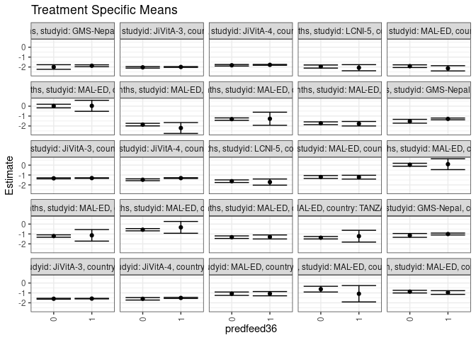

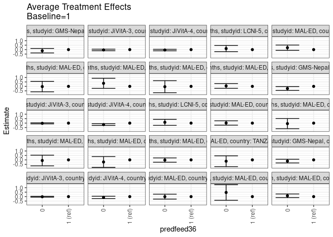

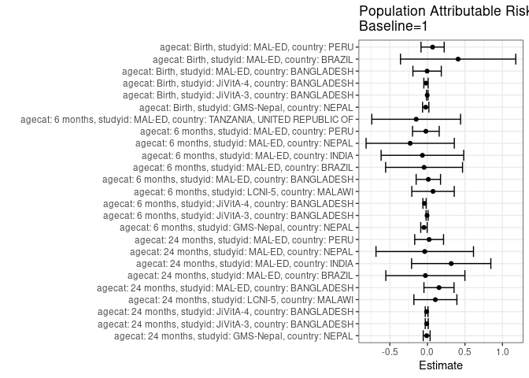

## Results Table

### Parameter: TSM

| agecat | studyid | country | intervention_level | baseline_level | estimate | ci_lower | ci_upper |
| --- | --- | --- | --- | --- | --- | --- | --- |
| Birth | GMS-Nepal | NEPAL | 1 | NA | -1.0070791 | -1.1029868 | -0.9111714 |
| Birth | GMS-Nepal | NEPAL | 0 | NA | -1.1441905 | -1.3372295 | -0.9511516 |
| Birth | JiVitA-3 | BANGLADESH | 1 | NA | -1.5733919 | -1.6013792 | -1.5454047 |
| Birth | JiVitA-3 | BANGLADESH | 0 | NA | -1.5872629 | -1.6321609 | -1.5423649 |
| Birth | JiVitA-4 | BANGLADESH | 1 | NA | -1.5041911 | -1.5574919 | -1.4508903 |
| Birth | JiVitA-4 | BANGLADESH | 0 | NA | -1.5953808 | -1.7192030 | -1.4715587 |
| Birth | MAL-ED | BANGLADESH | 1 | NA | -1.0758668 | -1.2910626 | -0.8606711 |
| Birth | MAL-ED | BANGLADESH | 0 | NA | -1.0793568 | -1.2516195 | -0.9070941 |
| Birth | MAL-ED | BRAZIL | 1 | NA | -1.0850000 | -1.9106873 | -0.2593127 |
| Birth | MAL-ED | BRAZIL | 0 | NA | -0.6185965 | -0.9082545 | -0.3289385 |
| Birth | MAL-ED | PERU | 1 | NA | -0.9601495 | -1.1474298 | -0.7728693 |
| Birth | MAL-ED | PERU | 0 | NA | -0.8696128 | -1.0046703 | -0.7345552 |
| 6 months | GMS-Nepal | NEPAL | 1 | NA | -1.2876522 | -1.3748203 | -1.2004841 |
| 6 months | GMS-Nepal | NEPAL | 0 | NA | -1.5266754 | -1.7206172 | -1.3327337 |
| 6 months | JiVitA-3 | BANGLADESH | 1 | NA | -1.3105045 | -1.3424564 | -1.2785526 |
| 6 months | JiVitA-3 | BANGLADESH | 0 | NA | -1.3324356 | -1.3871338 | -1.2777375 |
| 6 months | JiVitA-4 | BANGLADESH | 1 | NA | -1.3129019 | -1.3539742 | -1.2718297 |
| 6 months | JiVitA-4 | BANGLADESH | 0 | NA | -1.4792492 | -1.5725719 | -1.3859265 |
| 6 months | LCNI-5 | MALAWI | 1 | NA | -1.7143181 | -2.0250107 | -1.4036255 |
| 6 months | LCNI-5 | MALAWI | 0 | NA | -1.6240864 | -1.7544439 | -1.4937289 |
| 6 months | MAL-ED | BANGLADESH | 1 | NA | -1.2193614 | -1.4133182 | -1.0254045 |
| 6 months | MAL-ED | BANGLADESH | 0 | NA | -1.2019068 | -1.3509215 | -1.0528922 |
| 6 months | MAL-ED | BRAZIL | 1 | NA | 0.0921670 | -0.4562549 | 0.6405888 |
| 6 months | MAL-ED | BRAZIL | 0 | NA | 0.0370188 | -0.1129813 | 0.1870189 |
| 6 months | MAL-ED | INDIA | 1 | NA | -1.1387439 | -1.7213362 | -0.5561516 |
| 6 months | MAL-ED | INDIA | 0 | NA | -1.2101954 | -1.3315285 | -1.0888622 |
| 6 months | MAL-ED | NEPAL | 1 | NA | -0.3325000 | -0.9301243 | 0.2651243 |
| 6 months | MAL-ED | NEPAL | 0 | NA | -0.5702349 | -0.6852437 | -0.4552262 |
| 6 months | MAL-ED | PERU | 1 | NA | -1.3023654 | -1.5062681 | -1.0984626 |
| 6 months | MAL-ED | PERU | 0 | NA | -1.3244817 | -1.4527919 | -1.1961715 |
| 6 months | MAL-ED | TANZANIA, UNITED REPUBLIC OF | 1 | NA | -1.2240000 | -1.8175386 | -0.6304614 |
| 6 months | MAL-ED | TANZANIA, UNITED REPUBLIC OF | 0 | NA | -1.3768487 | -1.5024066 | -1.2512909 |
| 24 months | GMS-Nepal | NEPAL | 1 | NA | -1.8728272 | -1.9665142 | -1.7791403 |
| 24 months | GMS-Nepal | NEPAL | 0 | NA | -2.0004436 | -2.2321785 | -1.7687087 |
| 24 months | JiVitA-3 | BANGLADESH | 1 | NA | -1.9979847 | -2.0404385 | -1.9555310 |
| 24 months | JiVitA-3 | BANGLADESH | 0 | NA | -2.0341168 | -2.1119718 | -1.9562618 |
| 24 months | JiVitA-4 | BANGLADESH | 1 | NA | -1.7814589 | -1.8243689 | -1.7385488 |
| 24 months | JiVitA-4 | BANGLADESH | 0 | NA | -1.8255838 | -1.9038299 | -1.7473378 |
| 24 months | LCNI-5 | MALAWI | 1 | NA | -2.0712818 | -2.3787084 | -1.7638552 |
| 24 months | LCNI-5 | MALAWI | 0 | NA | -1.9530392 | -2.1111204 | -1.7949580 |
| 24 months | MAL-ED | BANGLADESH | 1 | NA | -2.1326320 | -2.3945418 | -1.8707222 |
| 24 months | MAL-ED | BANGLADESH | 0 | NA | -1.9179752 | -2.0547599 | -1.7811905 |
| 24 months | MAL-ED | BRAZIL | 1 | NA | 0.0336172 | -0.5206426 | 0.5878770 |
| 24 months | MAL-ED | BRAZIL | 0 | NA | 0.0100329 | -0.1714237 | 0.1914894 |
| 24 months | MAL-ED | INDIA | 1 | NA | -2.2075803 | -2.7564478 | -1.6587129 |
| 24 months | MAL-ED | INDIA | 0 | NA | -1.8639369 | -1.9937990 | -1.7340748 |
| 24 months | MAL-ED | NEPAL | 1 | NA | -1.2725000 | -1.9347673 | -0.6102327 |
| 24 months | MAL-ED | NEPAL | 0 | NA | -1.3095434 | -1.4315531 | -1.1875337 |
| 24 months | MAL-ED | PERU | 1 | NA | -1.7751749 | -2.0013148 | -1.5490350 |
| 24 months | MAL-ED | PERU | 0 | NA | -1.7271744 | -1.8668572 | -1.5874916 |

### Parameter: E(Y)

| agecat | studyid | country | intervention_level | baseline_level | estimate | ci_lower | ci_upper |
| --- | --- | --- | --- | --- | --- | --- | --- |
| Birth | GMS-Nepal | NEPAL | NA | NA | -1.0299620 | -1.1192344 | -0.9406896 |
| Birth | JiVitA-3 | BANGLADESH | NA | NA | -1.5762700 | -1.6018685 | -1.5506716 |
| Birth | JiVitA-4 | BANGLADESH | NA | NA | -1.5234724 | -1.5733491 | -1.4735957 |
| Birth | MAL-ED | BANGLADESH | NA | NA | -1.0802262 | -1.2151319 | -0.9453206 |
| Birth | MAL-ED | BRAZIL | NA | NA | -0.6760000 | -0.9521457 | -0.3998543 |
| Birth | MAL-ED | PERU | NA | NA | -0.8913004 | -1.0115814 | -0.7710195 |
| 6 months | GMS-Nepal | NEPAL | NA | NA | -1.3337634 | -1.4135810 | -1.2539459 |
| 6 months | JiVitA-3 | BANGLADESH | NA | NA | -1.3152982 | -1.3444394 | -1.2861570 |
| 6 months | JiVitA-4 | BANGLADESH | NA | NA | -1.3514886 | -1.3904044 | -1.3125729 |
| 6 months | LCNI-5 | MALAWI | NA | NA | -1.6395956 | -1.7592633 | -1.5199278 |
| 6 months | MAL-ED | BANGLADESH | NA | NA | -1.2072639 | -1.3248889 | -1.0896388 |
| 6 months | MAL-ED | BRAZIL | NA | NA | 0.0475758 | -0.0963508 | 0.1915023 |
| 6 months | MAL-ED | INDIA | NA | NA | -1.2055794 | -1.3250712 | -1.0860876 |
| 6 months | MAL-ED | NEPAL | NA | NA | -0.5621418 | -0.6752179 | -0.4490658 |
| 6 months | MAL-ED | PERU | NA | NA | -1.3230913 | -1.4314947 | -1.2146879 |
| 6 months | MAL-ED | TANZANIA, UNITED REPUBLIC OF | NA | NA | -1.3737037 | -1.4970489 | -1.2503585 |
| 24 months | GMS-Nepal | NEPAL | NA | NA | -1.8830717 | -1.9710591 | -1.7950844 |
| 24 months | JiVitA-3 | BANGLADESH | NA | NA | -2.0071989 | -2.0453355 | -1.9690623 |
| 24 months | JiVitA-4 | BANGLADESH | NA | NA | -1.7922845 | -1.8313538 | -1.7532153 |
| 24 months | LCNI-5 | MALAWI | NA | NA | -1.9651323 | -2.1053230 | -1.8249415 |
| 24 months | MAL-ED | BANGLADESH | NA | NA | -1.9783962 | -2.1050210 | -1.8517715 |
| 24 months | MAL-ED | BRAZIL | NA | NA | 0.0061144 | -0.1625850 | 0.1748138 |
| 24 months | MAL-ED | INDIA | NA | NA | -1.8906250 | -2.0165920 | -1.7646580 |
| 24 months | MAL-ED | NEPAL | NA | NA | -1.3082379 | -1.4282426 | -1.1882331 |
| 24 months | MAL-ED | PERU | NA | NA | -1.7524710 | -1.8736426 | -1.6312994 |

### Parameter: ATE

| agecat | studyid | country | intervention_level | baseline_level | estimate | ci_lower | ci_upper |
| --- | --- | --- | --- | --- | --- | --- | --- |
| Birth | GMS-Nepal | NEPAL | 1 | 1 | 0.0000000 | 0.0000000 | 0.0000000 |
| Birth | GMS-Nepal | NEPAL | 0 | 1 | -0.1371114 | -0.3450639 | 0.0708410 |
| Birth | JiVitA-3 | BANGLADESH | 1 | 1 | 0.0000000 | 0.0000000 | 0.0000000 |
| Birth | JiVitA-3 | BANGLADESH | 0 | 1 | -0.0138710 | -0.0620657 | 0.0343237 |
| Birth | JiVitA-4 | BANGLADESH | 1 | 1 | 0.0000000 | 0.0000000 | 0.0000000 |
| Birth | JiVitA-4 | BANGLADESH | 0 | 1 | -0.0911897 | -0.2251574 | 0.0427779 |
| Birth | MAL-ED | BANGLADESH | 1 | 1 | 0.0000000 | 0.0000000 | 0.0000000 |
| Birth | MAL-ED | BANGLADESH | 0 | 1 | -0.0034900 | -0.2795828 | 0.2726029 |
| Birth | MAL-ED | BRAZIL | 1 | 1 | 0.0000000 | 0.0000000 | 0.0000000 |
| Birth | MAL-ED | BRAZIL | 0 | 1 | 0.4664035 | -0.4086172 | 1.3414243 |
| Birth | MAL-ED | PERU | 1 | 1 | 0.0000000 | 0.0000000 | 0.0000000 |
| Birth | MAL-ED | PERU | 0 | 1 | 0.0905368 | -0.1162971 | 0.2973707 |
| 6 months | GMS-Nepal | NEPAL | 1 | 1 | 0.0000000 | 0.0000000 | 0.0000000 |
| 6 months | GMS-Nepal | NEPAL | 0 | 1 | -0.2390232 | -0.4517956 | -0.0262509 |
| 6 months | JiVitA-3 | BANGLADESH | 1 | 1 | 0.0000000 | 0.0000000 | 0.0000000 |
| 6 months | JiVitA-3 | BANGLADESH | 0 | 1 | -0.0219311 | -0.0812794 | 0.0374171 |
| 6 months | JiVitA-4 | BANGLADESH | 1 | 1 | 0.0000000 | 0.0000000 | 0.0000000 |
| 6 months | JiVitA-4 | BANGLADESH | 0 | 1 | -0.1663472 | -0.2669283 | -0.0657661 |
| 6 months | LCNI-5 | MALAWI | 1 | 1 | 0.0000000 | 0.0000000 | 0.0000000 |
| 6 months | LCNI-5 | MALAWI | 0 | 1 | 0.0902317 | -0.2454002 | 0.4258636 |
| 6 months | MAL-ED | BANGLADESH | 1 | 1 | 0.0000000 | 0.0000000 | 0.0000000 |
| 6 months | MAL-ED | BANGLADESH | 0 | 1 | 0.0174545 | -0.2276122 | 0.2625213 |
| 6 months | MAL-ED | BRAZIL | 1 | 1 | 0.0000000 | 0.0000000 | 0.0000000 |
| 6 months | MAL-ED | BRAZIL | 0 | 1 | -0.0551481 | -0.6243975 | 0.5141012 |
| 6 months | MAL-ED | INDIA | 1 | 1 | 0.0000000 | 0.0000000 | 0.0000000 |
| 6 months | MAL-ED | INDIA | 0 | 1 | -0.0714515 | -0.6668727 | 0.5239698 |
| 6 months | MAL-ED | NEPAL | 1 | 1 | 0.0000000 | 0.0000000 | 0.0000000 |
| 6 months | MAL-ED | NEPAL | 0 | 1 | -0.2377349 | -0.8463250 | 0.3708551 |
| 6 months | MAL-ED | PERU | 1 | 1 | 0.0000000 | 0.0000000 | 0.0000000 |
| 6 months | MAL-ED | PERU | 0 | 1 | -0.0221163 | -0.2633686 | 0.2191360 |
| 6 months | MAL-ED | TANZANIA, UNITED REPUBLIC OF | 1 | 1 | 0.0000000 | 0.0000000 | 0.0000000 |
| 6 months | MAL-ED | TANZANIA, UNITED REPUBLIC OF | 0 | 1 | -0.1528487 | -0.7595223 | 0.4538248 |
| 24 months | GMS-Nepal | NEPAL | 1 | 1 | 0.0000000 | 0.0000000 | 0.0000000 |
| 24 months | GMS-Nepal | NEPAL | 0 | 1 | -0.1276163 | -0.3763101 | 0.1210774 |
| 24 months | JiVitA-3 | BANGLADESH | 1 | 1 | 0.0000000 | 0.0000000 | 0.0000000 |
| 24 months | JiVitA-3 | BANGLADESH | 0 | 1 | -0.0361321 | -0.1225230 | 0.0502588 |
| 24 months | JiVitA-4 | BANGLADESH | 1 | 1 | 0.0000000 | 0.0000000 | 0.0000000 |
| 24 months | JiVitA-4 | BANGLADESH | 0 | 1 | -0.0441250 | -0.1289891 | 0.0407391 |
| 24 months | LCNI-5 | MALAWI | 1 | 1 | 0.0000000 | 0.0000000 | 0.0000000 |
| 24 months | LCNI-5 | MALAWI | 0 | 1 | 0.1182426 | -0.2278030 | 0.4642882 |
| 24 months | MAL-ED | BANGLADESH | 1 | 1 | 0.0000000 | 0.0000000 | 0.0000000 |
| 24 months | MAL-ED | BANGLADESH | 0 | 1 | 0.2146568 | -0.0794483 | 0.5087619 |
| 24 months | MAL-ED | BRAZIL | 1 | 1 | 0.0000000 | 0.0000000 | 0.0000000 |
| 24 months | MAL-ED | BRAZIL | 0 | 1 | -0.0235843 | -0.6076409 | 0.5604723 |
| 24 months | MAL-ED | INDIA | 1 | 1 | 0.0000000 | 0.0000000 | 0.0000000 |
| 24 months | MAL-ED | INDIA | 0 | 1 | 0.3436434 | -0.2210349 | 0.9083217 |
| 24 months | MAL-ED | NEPAL | 1 | 1 | 0.0000000 | 0.0000000 | 0.0000000 |
| 24 months | MAL-ED | NEPAL | 0 | 1 | -0.0370434 | -0.7104558 | 0.6363691 |
| 24 months | MAL-ED | PERU | 1 | 1 | 0.0000000 | 0.0000000 | 0.0000000 |
| 24 months | MAL-ED | PERU | 0 | 1 | 0.0480004 | -0.2124521 | 0.3084530 |

### Parameter: PAR

| agecat | studyid | country | intervention_level | baseline_level | estimate | ci_lower | ci_upper |
| --- | --- | --- | --- | --- | --- | --- | --- |
| Birth | GMS-Nepal | NEPAL | 1 | NA | -0.0228829 | -0.0649119 | 0.0191461 |
| Birth | JiVitA-3 | BANGLADESH | 1 | NA | -0.0028781 | -0.0134607 | 0.0077045 |
| Birth | JiVitA-4 | BANGLADESH | 1 | NA | -0.0192813 | -0.0478856 | 0.0093230 |
| Birth | MAL-ED | BANGLADESH | 1 | NA | -0.0043594 | -0.1935967 | 0.1848779 |
| Birth | MAL-ED | BRAZIL | 1 | NA | 0.4090000 | -0.3592436 | 1.1772436 |
| Birth | MAL-ED | PERU | 1 | NA | 0.0688491 | -0.0854107 | 0.2231089 |
| 6 months | GMS-Nepal | NEPAL | 1 | NA | -0.0461112 | -0.0889095 | -0.0033129 |
| 6 months | JiVitA-3 | BANGLADESH | 1 | NA | -0.0047937 | -0.0183585 | 0.0087712 |
| 6 months | JiVitA-4 | BANGLADESH | 1 | NA | -0.0385867 | -0.0605136 | -0.0166598 |
| 6 months | LCNI-5 | MALAWI | 1 | NA | 0.0747225 | -0.2082063 | 0.3576513 |
| 6 months | MAL-ED | BANGLADESH | 1 | NA | 0.0120975 | -0.1502889 | 0.1744839 |
| 6 months | MAL-ED | BRAZIL | 1 | NA | -0.0445912 | -0.5570687 | 0.4678863 |
| 6 months | MAL-ED | INDIA | 1 | NA | -0.0668355 | -0.6170213 | 0.4833503 |
| 6 months | MAL-ED | NEPAL | 1 | NA | -0.2296418 | -0.8175399 | 0.3582562 |
| 6 months | MAL-ED | PERU | 1 | NA | -0.0207259 | -0.1983716 | 0.1569197 |
| 6 months | MAL-ED | TANZANIA, UNITED REPUBLIC OF | 1 | NA | -0.1497037 | -0.7412167 | 0.4418093 |
| 24 months | GMS-Nepal | NEPAL | 1 | NA | -0.0102445 | -0.0560054 | 0.0355164 |
| 24 months | JiVitA-3 | BANGLADESH | 1 | NA | -0.0092142 | -0.0290634 | 0.0106351 |
| 24 months | JiVitA-4 | BANGLADESH | 1 | NA | -0.0108257 | -0.0293035 | 0.0076522 |
| 24 months | LCNI-5 | MALAWI | 1 | NA | 0.1061495 | -0.1803335 | 0.3926325 |
| 24 months | MAL-ED | BANGLADESH | 1 | NA | 0.1542358 | -0.0464141 | 0.3548856 |
| 24 months | MAL-ED | BRAZIL | 1 | NA | -0.0275028 | -0.5544156 | 0.4994100 |
| 24 months | MAL-ED | INDIA | 1 | NA | 0.3169553 | -0.2110396 | 0.8449503 |
| 24 months | MAL-ED | NEPAL | 1 | NA | -0.0357379 | -0.6854184 | 0.6139426 |
| 24 months | MAL-ED | PERU | 1 | NA | 0.0227039 | -0.1695959 | 0.2150037 |